# Bioinformatique

9 novembre 2018

## Bioinformatique

## Plan général du cours

Contenu:

1. Bases de bioinformatique et quelques applications sur l’étude des séquences nucléotidiques  
   8h S. Maury
2. Bases en informatique et applications bioinformatiques pour la génomique  
   4h O. Rogier et 4h A. Chateigner

## Plan de la partie 2

- TD 5 : bases informatiques et programmation
  - Structure d’un ordinateur, fonction des composants
  - Les langages de programmation : bash (awk, sed), python/perl, R - (C/C++)
- TD 6 : Du fasta au bam
  - Notions de pipeline, scripts, outils de bio-info pure (samtools)
  - Visualisation (gbrowse, IGV) et calling, détection de polymorphisme
- TD 7 : R des bases à l’analyse transcriptomique
  - R : bases, rapports, reprise des scripts bash à intégrer
  - R : RNAseq, analyses de données d’expression
- TD 8 : Ontologie, prédictions et évaluation
  - R : ontologies, prédictions et retour à la bio
  - Finish du script, réflexion sur la suite

## Go go go!

## R

## R, kessessé ?

- Langage de programmation
- Environnement mathématique
- Pour faire quoi ?
  - Traitement de données
  - Analyse statistique
  - Graphiques

## Les spécificités de R

- Environnement intégré
- Langage de programmation complet et autonome
- Interprété (pas compilé comme C)
- Puissant en mathématiques et statistiques
- Multiplateforme
- Libre et ouvert
- De plus
  - Langage **vectorisé** <– Super super super important

## Ouvrons R

- Ouvrez un terminal
- Tapez R

[figure not shown]

- C’est pas folichon,  
  mais ça fait quoi ?

## Premières commandes

```r
Hello world!
```

```
## Error: <text>:1:7: unexpected symbol
## 1: Hello world
##           ^
```

```r
print("Hello world!")
2 + 3; 2 - 3; 2 * 3; 2 / 3; 2 ** 3; 2 ^ 3
```

```
## [1] "Hello world!"
## [1] 5
## [1] -1
## [1] 6
## [1] 0.6666667
## [1] 8
## [1] 8
```

## Objets et assignations

```r
a <- 2
b <- 3
a + b; a - b; a * b; a / b; a ** b; a ^ b
```

```
## [1] 5
## [1] -1
## [1] 6
## [1] 0.6666667
## [1] 8
## [1] 8
```

## Objets et assignations

On peut réutiliser un objet:

```r
a <- 1
a
a <- 2
a
a ** b
```

```
## [1] 1
## [1] 2
## [1] 8
```

## Et à la fin

- Question : on garde quoi à la fin ?
  - Les objets créés ? `a ** b`
  - Le code ?
- Code réel et objets virtuels
  - Garder le code permet de refaire toute une analyse
  - On garde le code dans des scripts
  - Contiennent toute la démarche
  - Gain d’espace de stockage

## Les scripts

## Sauvegarder l’avancée de son travail : le script

- Programmation: A quoi ça sert ?

[figure not shown]

- Gain de temps
- Répétition de tâches
- Tracabilité

## Sauvegarder son travail en mieux : le rapport !

- Traçabilité des actions (pas de clic clic)
- Regrouper code et résultats
- Faire un rapport quoi…
- Ouvrons RStudio

[figure not shown]

## Rmarkdown

- `R` + `markdown` (langage à balisage léger)
- Code `R` et commentaires
- Faisons tout de suite un rapport qui a :
  - Des titres structurés et numérotés
  - Une table des matières
  - Des chunks avec des noms
  - Du code
  - Qu’il produise un rapport html
  - Que sa date soit automatique
    - date: “`` `r substr(Sys.time(), 1, 10)` ``”

## Un rapport structuré : exemple et évaluation

https://bit.ly/m2BICGRapport

Tâche fil rouge : rapport de la partie 2 du cours

**–> Evaluation**

## Back to the futuRe

## Rappel

```r
print("Hello world!")
a <- 2; b <- 3
a ** b
```

```
## [1] "Hello world!"
## [1] 8
```

## Répertoire de travail

- Dossier dans lequel vous travaillez
- Même endroit que votre script/rapport
- Implique que les objets soient placés par rapport à lui

Exemple, pour lire un fichier csv:

```r
# bien
objet1 <- read.csv(file = "dossier/fichier1.csv")
# pas bien
objet1 <- read.csv(file = "C:/User/achateigner/Documents/.../dossier/fichier1.csv")
```

## Aide

Plusieurs méthodes :

- dans R :

```r
?ls
help("ls")
```

- dans Rstudio :

[figure not shown]

## Les fonctions

- En R, une fonction s’écrit avec des parenthèses, e.g. `ls()`
- Beaucoup déjà écrites
- Vous pouvez faire les vôtres
  - Partage simple sur github
  - Partage sous forme de package sur CRAN et Bioconductor

## Les packages

- Ajout de nouvelles fonctions
- Doivent être chargés pour utiliser directement leurs fonctions
- On peut aussi appeler directement `Package::fonction()`
- 3 répertoires principaux : CRAN, Bioconductor, github
- 1 package pour les installer tous : anyLib

```r
# Installation classique
install.packages("anyLib")
# Chargement d'un paquet
library(anyLib)
# Avec anyLib, les deux d'un coup
anyLib("apercu")
```

```r
# Installation avec bioconductor
# d'abord, on installe bioconductor
if (!requireNamespace("BiocManager"))
    install.packages("BiocManager")
BiocManager::install()
# ensuite on installe le paquet
BiocManager::install("coseq")
# enfin on le charge
library(coseq)
# Avec anyLib :
anyLib("coseq")
```

```r
# Installation avec github
# D'abord, il faut le paquet devtools
install.packages("devtools")
# Ensuite on le charge
library(devtools)
# Enfin on installe le package
install_github("achateigner/loadAllChunksCache")
# Avec anyLib
anyLib("achateigner/loadAllChunksCache")
```

## Les packages

- Ajout de nouvelles fonctions
- Doivent être chargés pour utiliser directement leurs fonctions
- On peut aussi appeler directement `Package::fonction()`
- 3 répertoires principaux : CRAN, Bioconductor, github
- 1 package pour les installer tous : anyLib

Vous pouvez aussi les installer et charger en clic clic mais :

- Bonjour la tracabilité
- C’est moins swag

## anyLib

```r
install.packages("anyLib")
library(anyLib)
packagesNeeded <- c("captioner", "apercu", "viridis")
anyLib(packagesNeeded)
```

- Permet d’installer/de charger plusieurs packages à la fois
- Permet de les installer du CRAN, de bioconductor ou de github en 1 fois
- Renvoie un vecteur de booléen nommé de réussite ou d’échec

## Evaluation 1

1. Installez les packages `apercu` du CRAN, `limma` sur Bioconductor et `achateigner/loadAllChunksCache` de github, efficacement
2. Chargez ces packages
3. Donnez le nom de l’auteur/créateur de chacun de ces packages (utilisez `packageDescription` ou `citation`)
4. Quelles sont les versions installées de ces packages ? Où/comment avez-vous trouvé cette information ? (vous devriez pouvoir trouver la fonction nécessaire en réfléchissant un peu)

## Import/Export

## Sauver des objets et une session

- Quand on veut sauvegarder son travail on peut sauver une image de session :

```r
save.image(file = "nomDeLObjetSession.rda")
```

- On peut aussi sauver les objets directement

```r
save(a, file = "nomDeLObjet.rda")
```

- Ou encore sauver un fichier texte, un tableau

```r
write(a, file = "fichierTexte.txt")
matrice <- matrix(1:4, ncol = 2)
write.table(matrice, file = "matrix.csv")
write.csv(matrice, file = "matrix2.csv")
```

## Importer des objets d’Aliexpress

- Quand on veut charger une ancienne session

```r
load(file = "nomDeLObjetSession.rda")
```

- Quand on veut charger un objet, même chose

```r
load(file = "nomDeLObjet.rda")
```

- Quand on veut charger un fichier texte ou un tableau

```r
read.table("fichierTexte.txt")
matrice <- read.table(file = "matrix.csv")
matrice2 <- read.csv(file = "matrix2.csv", row.names = 1)
```

## Evaluation 2

1. Sauvegardez l’objet contenant les trois packages à installer de l’évaluation 1 dans votre dossier courrant
2. Fermez votre Rstudio puis rouvrez-le et chargez ce même objet

## Les bases de la syntaxe

## Les commandes R

L’utilisateur interagit avec l’interprète R en entrant une commande :

- Soit une expression
- Soit une affectation

## Les commandes R

L’utilisateur interagit avec l’interprète R en entrant une commande :

- Soit une expression

```r
2 + 3
pi
cos(pi / 4)
```

```
## [1] 5
## [1] 3.141593
## [1] 0.7071068
```

## Les commandes R

L’utilisateur interagit avec l’interprète R en entrant une commande :

- Soit une expression
- Soit une affectation

```r
a <- 5
a
b <- a
b
(a <- 2 + 3)
```

```
## [1] 5
## [1] 5
## [1] 5
```

## Quelques détails

- -> = ;
- Regroupement de commandes avec {} :

```r
{
    a <- 2 + 3
    b <- a
    b
}
```

```
## [1] 5
```

- Résultat de la dernière commande

## Conventions de noms

- Autorisés : A-Za-z0-9._
- Autorisés mais déconseillés : les caractères accentués
- Interdit : démarrer par un chiffre
- Interdit : démarrer par .[0-9]
- Sensible à la casse : foo =/= Foo
- Déconseillé : réutiliser des noms de R (c, q, t, C, D, I, diff, length, mean…)
- Mots interdits car réservés :
  - break, else, for, function, if, in, next, repeat, return, while,
  - TRUE, FALSE,
  - Inf, NA, NaN, NULL,
  - NA_integer_, NA_real_, NA_complex_, NA_character_,
  - …, ..1, ..2, etc.

## TRUE or FALSE

- `T` veut dire `TRUE`
- `F` veut dire `FALSE`
- `TRUE` vaut 1 et `FALSE` vaut 0 si on les somme (`sum()`)
- Mais préférez `TRUE` et `FALSE` car

```r
TRUE <- 3
```

```
## Error in TRUE <- 3: membre gauche de l'assignation (do_set) incorrect
```

```r
T <- 3
```

## Les objets

## Les objets

Tout en R est un objet :

- Les variables contenant des données
- Les fonctions
- Les opérateurs
- Même le symbole représentant le nom d’un objet

Ils ont :

- Un mode (unique)
- Une longueur
- Des attributs (facultatif)

```r
v <- c(1, 2, 5, 9)
mode(v)
length(v)
```

```
## [1] "numeric"
## [1] 4
```

## Modes et types de données

| Mode | Contenu de l’objet |
| --- | --- |
| numeric | nombres réels |
| complex | nombres complexes |
| logical | valeurs booléennes (vrai/faux) |
| character | chaînes de caractères |
| function | fonction |
| list | données quelconques |
| expression | expressions non évaluées |

## Objets simples ou récursifs

- Objets simples : numeric, complex, logical et character = 1 seul type de données
- Objets récursifs : list et expression = peuvent contenir d’autres objets
- `typeof` : description de la représentation internet d’un objet, comment il est stocké
- `class` : description qui nous intéresse, un objet peut en avoir plusieurs

## Longueur

Egal au nombre d’éléments contenus dans l’objet

```r
v1 <- "actuariat"
length(v1)
nchar(v1)
v2 <- c("a", "c", "t", "u", "a", "r", "i", "a", "t")
length(v2)
nchar(v2)
v <- numeric(0) #objet vide
length(v)
```

```
## [1] 1
## [1] 9
## [1] 9
## [1] 1 1 1 1 1 1 1 1 1
## [1] 0
```

## NULL

Objet spécial, représentant “rien”, le vide

```r
typeof(NULL)
class(NULL)
length(NULL)
identical(NULL, numeric(0))
is.null(NULL)
```

```
## [1] "NULL"
## [1] "NULL"
## [1] 0
## [1] FALSE
## [1] TRUE
```

## Données manquantes : `NA`

- logical mais ni `TRUE` ni `FALSE`
- toute opération l’impliquant a pour résultat `NA`
- `na.rm`

```r
NA == NA
NA != NA
is.na(NA)
```

```
## [1] NA
## [1] NA
## [1] TRUE
```

## Autres valeurs spéciales

- `Inf` et `-Inf`
- NaN : not a number
- `is.infinite`, `is.finite`, `is.nan`

## Attributs

Eléments d’information additionnels d’un objet

| Attribut | Utilisation |
| --- | --- |
| class | affecte le comportement d’un objet |
| dim | dimensions des matrices et tableaux |
| dimnames | étiquettes des dimensions des matrices et tableaux |
| names | étiquettes des éléments d’un objet |

## Attributs

```r
x <- 3
attr(x, "methode") <- "au pif"
attributes(x)
dim(x)
attr(x, "methode") <- NULL
attributes(x)
```

```
## $methode
## [1] "au pif"
##
## NULL
## NULL
```

## Vecteurs, matrices, tableaux, listes et data frames

## Vecteurs

- En R, tout est vecteur. C’est l’unité de base dans les calculs
- Tous les éléments doivent être du même mode
- Fonctions de base de création de vecteur :
  - `c`
  - `numeric`
  - `logical`
  - `character`

## Vecteurs

On peut donner une étiquette/un nom à chaque élément

```r
(v <- c(a = 1, b = 2, c = 5))
v <- c(1, 2, 5)
names(v) <- c("a", "b", "c")
v
```

```
## a b c
## 1 2 5
## a b c
## 1 2 5
```

## Matrices et tableaux

- Matrice = vecteur avec un attribut `dim` de longueur 2

```r
attr(x, "dim") <- c(1, 1)
class(x)
matrix(1:6, nrow = 2, ncol = 3)
(m <- matrix(1:6, nrow = 2, ncol = 3, byrow = TRUE))
```

```
## [1] "matrix"
##      [,1] [,2] [,3]
## [1,]    1    3    5
## [2,]    2    4    6
##      [,1] [,2] [,3]
## [1,]    1    2    3
## [2,]    4    5    6
```

## Matrices et tableaux

- Tableaux = vecteur à plus de 2 dimensions

```r
attr(x, "dim") <- c(1, 1, 1)
class(x)
(a <- array(1:24, dim = c(3, 4, 2)))
```

```
## [1] "array"
## , , 1
##
##      [,1] [,2] [,3] [,4]
## [1,]    1    4    7   10
## [2,]    2    5    8   11
## [3,]    3    6    9   12
##
## , , 2
##
##      [,1] [,2] [,3] [,4]
## [1,]   13   16   19   22
## [2,]   14   17   20   23
## [3,]   15   18   21   24
```

- Convension de remplissage par colonne

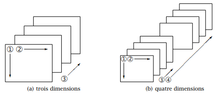

## Listes

- Vecteur spécial
- Elements de n’importe quel mode (même liste)
- Mode de stockage le plus polyvalent

```r
(l <- list(size = c(1, 5, 2), user = "Joe", new = TRUE))
```

```
## $size
## [1] 1 5 2
##
## $user
## [1] "Joe"
##
## $new
## [1] TRUE
```

## Data frames

- Matrice spéciale, en réalité une liste d’éléments de même longueur
- De classe `data.frame`
- Matrice avec colonnes de modes différents
- `data.frame()` et `as.data.frame()`
- `rbind()` et `cbind()`

```r
d <- data.frame(num = 1:3, letter = letters[1:3])
```

## Evaluation 3

1. Affectez à un vecteur la sortie du chargement des packages demandés à l’évaluation 1
2. Affectez à un autre vecteur le nom des auteurs de chaque package, dans l’ordre
3. Affectez à un autre vecteur la version de chaque package, dans l’ordre, et sans les taper à la main (sauf si vous n’avez pas le choix)
4. Sauvez votre session
5. Construisez une data frame contenant les vecteurs des points 1 à 3

## Indiçage

## Indiçage des vecteurs

```r
v[3]
v["c"]
v["c"] <- 10
v
```

```
## c
## 5
## c
## 5
##  a  b  c
##  1  2 10
```

## 5 manières d’indicer un vecteur

```r
x <- c(A = 2, B = 4, C = -1, D = -5, E = 8)
x[c(1, 3)] #1
x[c(-2, -3)] #2
x > 0
x[x > 0] #3
x[c("B", "D")] #4
x[] #5
```

```
##  A  C
##  2 -1
##  A  D  E
##  2 -5  8
##     A     B     C     D     E
##  TRUE  TRUE FALSE FALSE  TRUE
## A B E
## 2 4 8
##  B  D
##  4 -5
##  A  B  C  D  E
##  2  4 -1 -5  8
```

## Indiçage des matrices et tableaux

```r
m[1,2]
m[3]
m[2,]
a[1,1,1]
```

```
## [1] 2
## [1] 2
## [1] 4 5 6
## [1] 1
```

## Indiçage des listes

```r
l[1]
l[[1]]
l$size
l[c(1,2)]
l[[c(1,2)]]
l$size[2]
unlist(l)
```

```
## $size
## [1] 1 5 2
##
## [1] 1 5 2
## [1] 1 5 2
## $size
## [1] 1 5 2
##
## $user
## [1] "Joe"
##
## [1] 5
## [1] 5
##  size1  size2  size3   user    new
##    "1"    "5"    "2"  "Joe" "TRUE"
```

## Indiçage des data frames

```r
d[1]
d[1:2]
d[1,1]
d$num
d$num[1]
d[[c(2,1)]]
d[c(2,1)]
d[2][[1]][1]
```

[output not shown]

## Bonus de l’indicage

```r
?`[`
?`[<-`
`[`
?`$`
?`$<-`
```

## Evaluation 4

A partir de votre data frame précédente, extrayez les informations suivantes :

1. L’auteur du package `apercu`
2. La version du package `limma`
3. Le nombre de packages correctement chargés
4. Le nombre de packages écrits par Aurelien Chateigner
5. Le nombre de packages écrits par quelqu’un d’autre
6. La classe de la colonne chargement
7. La classe de la colonne auteurs
8. La première classe de la colonne versions
9. Les détails du package `limma`

## Les graphiques

https://bioinfo-fr.net/cours-de-r-pour-debutant-presse-intro  
https://bioinfo-fr.net/cours-de-r-pour-debutant-presse-deuxieme-episode  
https://bioinfo-fr.net/cours-de-r-pour-debutant-presse-les-regressions